# Trabajo Práctico Individual Nº 3: Regresión Logística

Autor/a

Yazmin Dellacasa

Fecha de publicación

18 de junio de 2026

```r
#Cargo las librerias que voy a usar
if (!require("pacman")) install.packages("pacman")
pacman::p_load(tidyverse, broom, modelsummary, kableExtra, marginaleffects, yardstick, here)
```

[output not shown]

```r
adult_data <- read_csv(here("TP3", "data", "adult_census_USA.csv"))

# Limpieza y preparación
df_clean <- adult_data |>
  mutate(
    # income: <=50K es la base, >50K es el 1 (lo que quiero predecir)
    income = factor(income, levels = c("<=50K", ">50K")),

    # Simplifico el estado civil a 2 categorías
    marital_status = case_when(
      marital_status %in% c("Married-civ-spouse", "Married-spouse-absent", "Married-AF-spouse") ~ "Married",
      TRUE ~ "Single/Other"
    ),
    marital_status = factor(marital_status, levels = c("Single/Other", "Married")),

    # Sexo como factor explícito
    sex = factor(sex, levels = c("Female", "Male"))
  )
```

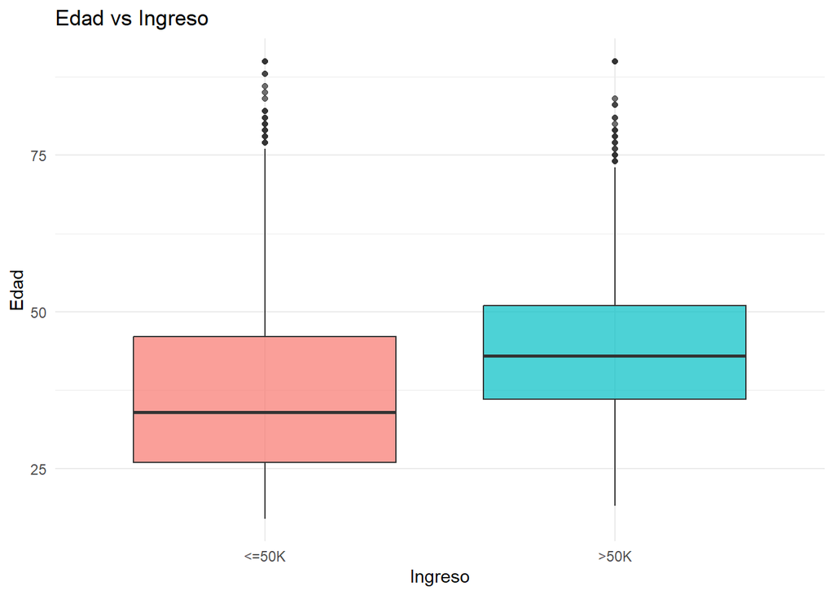

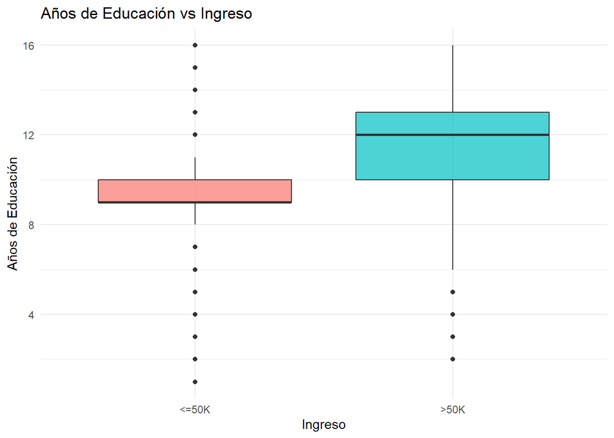

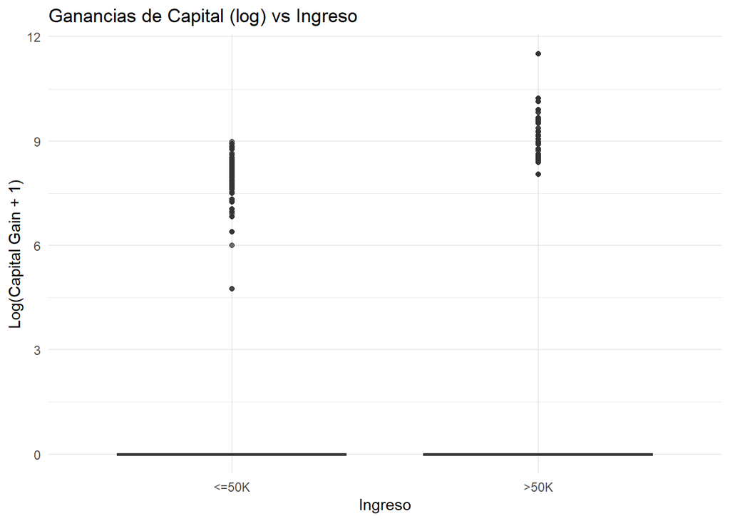

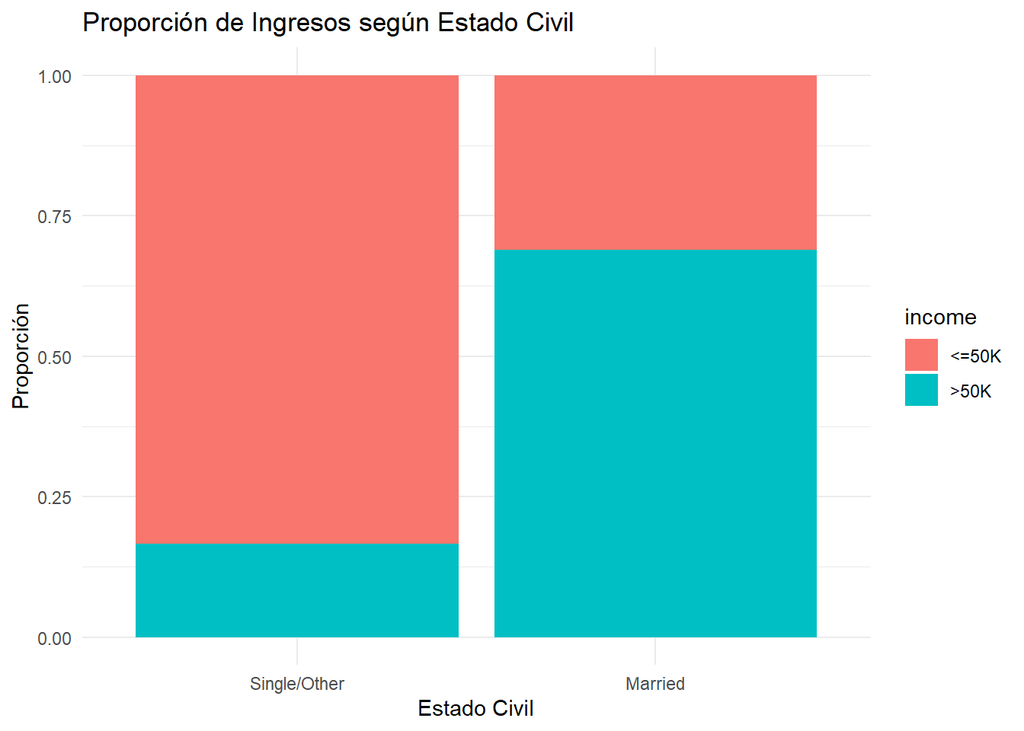

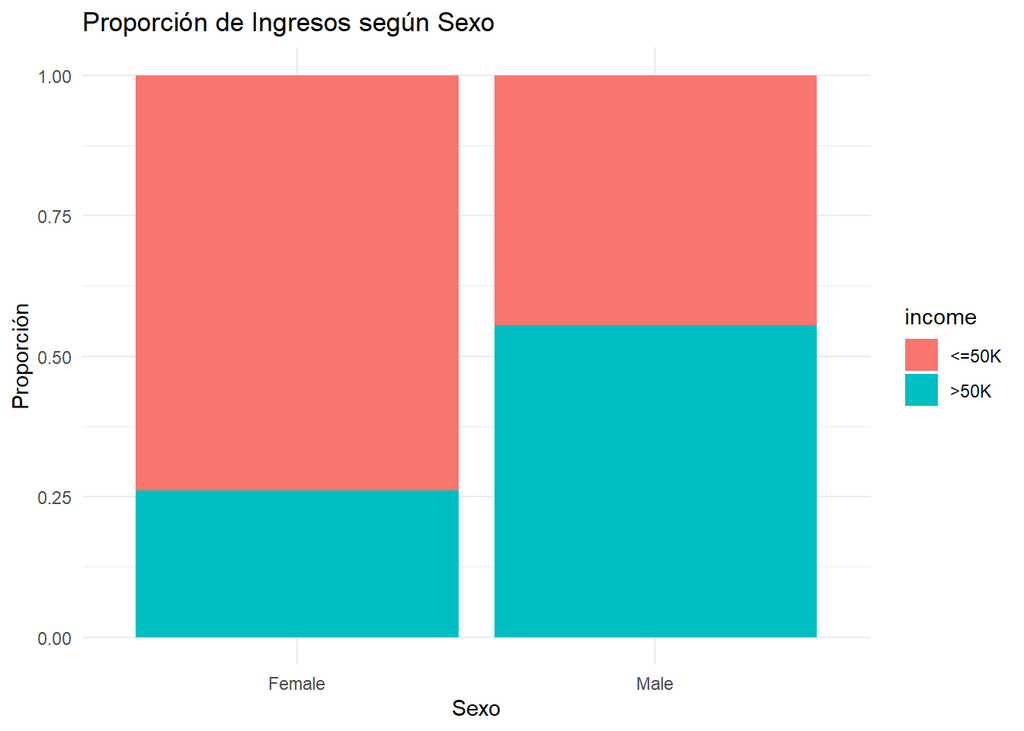

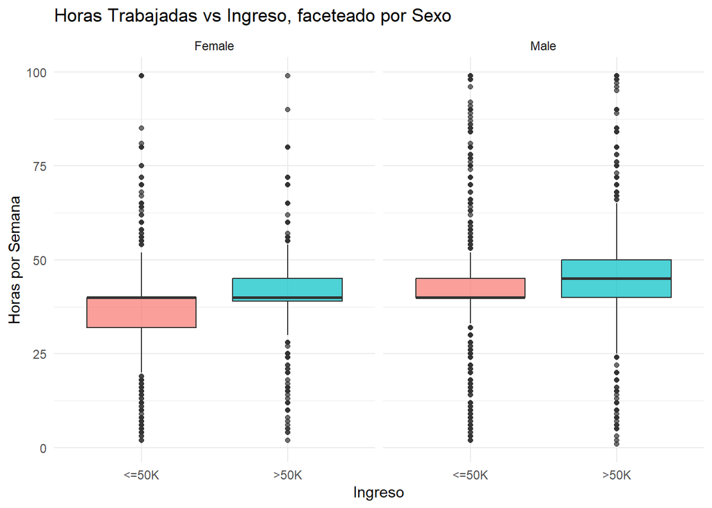

```r
# 1. Edad vs Ingreso
ggplot(df_clean, aes(x = income, y = age, fill = income)) +
  geom_boxplot(alpha = 0.7) + theme_minimal() +
  labs(title = "Edad vs Ingreso", x = "Ingreso", y = "Edad") +
  theme(legend.position = "none")
# 2. Educación vs Ingreso
ggplot(df_clean, aes(x = income, y = education_num, fill = income)) +
  geom_boxplot(alpha = 0.7) + theme_minimal() +
  labs(title = "Años de Educación vs Ingreso", x = "Ingreso", y = "Años de Educación") +
  theme(legend.position = "none")
# 3. Ganancias de Capital (Log) vs Ingreso
ggplot(df_clean, aes(x = income, y = log1p(capital_gain), fill = income)) +
  geom_boxplot(alpha = 0.7) + theme_minimal() +
  labs(title = "Ganancias de Capital (log) vs Ingreso", x = "Ingreso", y = "Log(Capital Gain + 1)") +
  theme(legend.position = "none")
# 4. Estado Civil vs Ingreso
ggplot(df_clean, aes(x = marital_status, fill = income)) +
  geom_bar(position = "fill") + theme_minimal() +
  labs(title = "Proporción de Ingresos según Estado Civil", x = "Estado Civil", y = "Proporción")
# 5. Sexo vs Ingreso
ggplot(df_clean, aes(x = sex, fill = income)) +
  geom_bar(position = "fill") + theme_minimal() +
  labs(title = "Proporción de Ingresos según Sexo", x = "Sexo", y = "Proporción")
# 6. Interacción: Horas de Trabajo vs Ingreso faceteado por Sexo
ggplot(df_clean, aes(x = income, y = hours_per_week, fill = income)) +
  geom_boxplot(alpha = 0.7) + theme_minimal() +
  facet_wrap(~ sex) +
  labs(title = "Horas Trabajadas vs Ingreso, faceteado por Sexo",
       x = "Ingreso", y = "Horas por Semana") +
  theme(legend.position = "none")
```

**Justificación teórica de la interacción:** Se incluye el término de interacción entre las horas de trabajo (`hours_per_week`) y el sexo (`sex`) por la hipótesis de que el mercado laboral presenta asimetrías de género. Esto implica que el “retorno” económico de trabajar más horas (su impacto en la probabilidad de percibir ingresos mayores a $50K) no es homogéneo, sino que está condicionado por el género del individuo. El último gráfico nos permite ver esta decisión al exponer las distintas distribuciones de horas trabajadas según el sexo dentro de cada estrato de ingresos.

## 2. Ajuste de Modelos (Regresión Logística)

**Categorías de Referencia:**

Para fla interpretación del intercep y de los coeficientes, en la limpieza de datos estableci estas categoriaategorías base: * **Variable Dependiente (income):** `<=50K` (referencia 0) * **Sexo (sex):** `Female` * **Estado Civil (marital_status):** `Single/Other`

voy a ajusatr dos modelos usando `glm()` con la familia binomial (enlace logit). El primero va a ser el modelo base y el en el segundo voy a agregar el término de interacción que justifique en el análisis exploratorio.

```r
# Modelo 1 (Base): sin interacciones
modelo_1 <- glm(income ~ age + education_num + hours_per_week + sex + marital_status + log1p(capital_gain),
                data = df_clean,
                family = binomial(link = "logit"))

# Modelo 2 (Interactivo): incluye hours_per_week interactuando con sex
modelo_2 <- glm(income ~ age + education_num + hours_per_week * sex + marital_status + log1p(capital_gain),
                data = df_clean,
                family = binomial(link = "logit"))

# Aca pongo summary estadístico de ambos modelos
summary(modelo_1)
```

```
Call:
glm(formula = income ~ age + education_num + hours_per_week +
    sex + marital_status + log1p(capital_gain), family = binomial(link = "logit"),
    data = df_clean)

Coefficients:
                       Estimate Std. Error z value Pr(>|z|)
(Intercept)           -8.949096   0.176161 -50.801  < 2e-16 ***
age                    0.035426   0.001875  18.899  < 2e-16 ***
education_num          0.382671   0.009798  39.057  < 2e-16 ***
hours_per_week         0.034695   0.002105  16.478  < 2e-16 ***
sexMale                0.226324   0.055772   4.058 4.95e-05 ***
marital_statusMarried  2.356859   0.052393  44.984  < 2e-16 ***
log1p(capital_gain)    0.197551   0.008711  22.679  < 2e-16 ***
---
Signif. codes:  0 '***' 0.001 '**' 0.01 '*' 0.05 '.' 0.1 ' ' 1

(Dispersion parameter for binomial family taken to be 1)

    Null deviance: 21821  on 15765  degrees of freedom
Residual deviance: 13556  on 15759  degrees of freedom
AIC: 13570

Number of Fisher Scoring iterations: 5
```

```r
summary(modelo_2)
```

```
Call:
glm(formula = income ~ age + education_num + hours_per_week *
    sex + marital_status + log1p(capital_gain), family = binomial(link = "logit"),
    data = df_clean)

Coefficients:
                        Estimate Std. Error z value Pr(>|z|)
(Intercept)            -8.685046   0.221193 -39.265  < 2e-16 ***
age                     0.035523   0.001873  18.965  < 2e-16 ***
education_num           0.383393   0.009812  39.075  < 2e-16 ***
hours_per_week          0.027822   0.004108   6.773 1.26e-11 ***
sexMale                -0.149931   0.201644  -0.744   0.4572
marital_statusMarried   2.351391   0.052427  44.850  < 2e-16 ***
log1p(capital_gain)     0.197631   0.008707  22.697  < 2e-16 ***
hours_per_week:sexMale  0.009249   0.004767   1.940   0.0524 .
---
Signif. codes:  0 '***' 0.001 '**' 0.01 '*' 0.05 '.' 0.1 ' ' 1

(Dispersion parameter for binomial family taken to be 1)

    Null deviance: 21821  on 15765  degrees of freedom
Residual deviance: 13552  on 15758  degrees of freedom
AIC: 13568

Number of Fisher Scoring iterations: 5
```

## 3. Interpretación de Resultados y Efectos Marginales

```r
# Calculo los AME  para el Modelo 2 (Interactivo)
efectos_marginales <- avg_comparisons(modelo_2)

# Presentación estandarizada en tabla HTML
efectos_marginales |>
  select(term, contrast, estimate, conf.low, conf.high, p.value) |>
  kable(digits = 4, caption = "Efectos Marginales Promedio (AME) - Modelo Interactivo") |>
  kable_styling(bootstrap_options = c("striped", "hover"), full_width = FALSE)
```

Efectos Marginales Promedio (AME) - Modelo Interactivo

| term | contrast | estimate | conf.low | conf.high | p.value |
| --- | --- | --- | --- | --- | --- |
| age | +1 | 0.0049 | 0.0044 | 0.0054 | 0 |
| capital_gain | +1 | 0.0174 | 0.0159 | 0.0189 | 0 |
| education_num | +1 | 0.0529 | 0.0507 | 0.0551 | 0 |
| hours_per_week | +1 | 0.0048 | 0.0043 | 0.0054 | 0 |
| marital_status | Married - Single/Other | 0.3876 | 0.3723 | 0.4028 | 0 |
| sex | Male - Female | 0.0355 | 0.0193 | 0.0516 | 0 |

**Interpretación de Efectos Marginales Promedio (AME):**

Al analizar los AME solamente del modelo interactivo, puedo ver el impacto promedio de cada variable sobre la probabilidad de percibir ingresos mayores a $50,000, manteniendo el resto constante:

- **Estado Civil:** Es el factor sociodemográfico de mas peso individual. Estar casado (frente a estar soltero u otro estado) aumenta la probabilidad promedio de tener de altos ingresos de forma contundente.
- **Capital Humano y Experiencia:** Veo un efecto positivo, osea cada año adicional de educación (education_num) y cada año mas de edad (age) aumentan las chances de superar el umbral de ingresos.
- **Dinámica Laboral y Brecha de Género:** Cada hora extra de trabajo semanal (hours_per_week) incrementa en promedio la probabilidad de altos ingresos. Al mismo tiempo, el AME para la variable sexo (`Male` vs `Female`) veo la diferencia promedio en probabilidad a favor de los hombres, aca es donde veo la asimetría del mercado laboral a través de todos los niveles de horas trabajadas.
- **Ganancias de Capital:** Un aumento en el logaritmo de esta variable tiene un impacto positivo en la probabilidad de estar en el grupo de mayores ingresos.

Ahora, vemos los Odds Ratios con un Forest Plot:

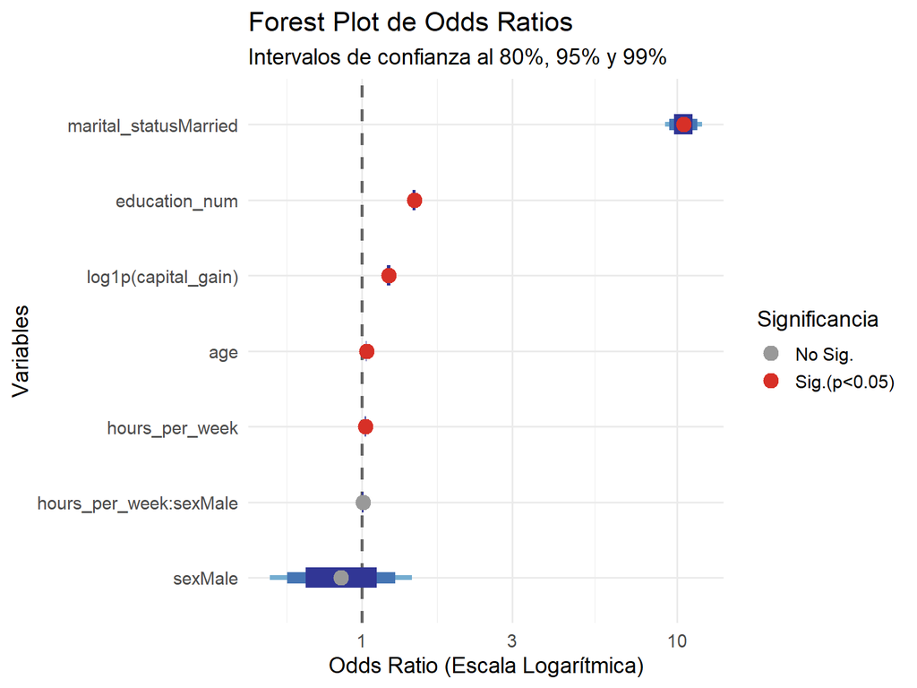

```r
# Aca lo que hago es extraerlos coeficientes de log-odds y calculo manualmente los intervalos
or_df <- broom::tidy(modelo_2, conf.int = FALSE) |>
  mutate(
    lo_99 = exp(estimate - 2.576 * std.error),
    hi_99 = exp(estimate + 2.576 * std.error),
    lo_95 = exp(estimate - 1.96 * std.error),
    hi_95 = exp(estimate + 1.96 * std.error),
    lo_80 = exp(estimate - 1.28 * std.error),
    hi_80 = exp(estimate + 1.28 * std.error),
    estimate = exp(estimate), # Transformamos a Odds Ratios
    # 1. CREAMOS LA VARIABLE DE SIGNIFICANCIA mirando el p.value
    Significancia = ifelse(p.value < 0.05, "Sig.(p<0.05)", "No Sig.")
  ) |>
  filter(term != "(Intercept)")

# Gráfico
ggplot(or_df, aes(y = reorder(term, estimate), x = estimate)) +
  geom_vline(xintercept = 1, linetype = "dashed", color = "gray40", linewidth = 1) +
  geom_linerange(aes(xmin = lo_99, xmax = hi_99), color = "#74ADD1", linewidth = 1.5) +
  geom_linerange(aes(xmin = lo_95, xmax = hi_95), color = "#4575B4", linewidth = 3.5) +
  geom_linerange(aes(xmin = lo_80, xmax = hi_80), color = "#313695", linewidth = 6) +
  # 2. PONEMOS EL COLOR ADENTRO DEL aes()
  geom_point(aes(color = Significancia), size = 4) +
  scale_color_manual(
    # Rojo si es significativo, gris si no lo es
    values = c("Sig.(p<0.05)" = "#D73027", "No Sig." = "gray60"),
    name = "Significancia"
  ) +
  scale_x_log10() +
  theme_minimal(base_size = 14) +
  labs(title = "Forest Plot de Odds Ratios",
       subtitle = "Intervalos de confianza al 80%, 95% y 99%",
       x = "Odds Ratio (Escala Logarítmica)",
       y = "Variables")
```

## 4. Comparación Global de Modelos

Ahora comparo el desempeño del modelo base frente al interactivo utilizando la función `glance()` del paquete.

```r
# Tabla comparativa calculando el Pseudo-R2
glance_m1 <- broom::glance(modelo_1) |>
  mutate(Modelo = "1. Base", Pseudo_R2 = 1 - (deviance / null.deviance))
glance_m2 <- broom::glance(modelo_2) |>
  mutate(Modelo = "2. Interactivo", Pseudo_R2 = 1 - (deviance / null.deviance))

bind_rows(glance_m1, glance_m2) |>
  select(Modelo, AIC, deviance, null.deviance, Pseudo_R2) |>
  kable(digits = 3, caption = "Comparación de Modelos Logísticos") |>
  kable_styling(bootstrap_options = c("striped", "hover"), full_width = FALSE)
```

Comparación de Modelos Logísticos

| Modelo | AIC | deviance | null.deviance | Pseudo_R2 |
| --- | --- | --- | --- | --- |
| 1. Base | 13569.60 | 13555.60 | 21820.62 | 0.379 |
| 2. Interactivo | 13567.86 | 13551.86 | 21820.62 | 0.379 |

**Interpretación:**

Para sabeer si se justifica armar el **Modelo 2 (con la interacción)** o si quedarme con el **Modelo 1 (base)** vemos:

**¿El término de interacción mejora el modelo?** Sí, la inclusión de la interacción mejora levemente el modelo. Los indicadores muestran que cruzar las horas de trabajo con el sexo del individuo aporta un poder explicativo adicional (aunque marginal) para predecir si alguien gana más de $50,000.